# ALCINA — Survival analyses

HES-1, circulating tumor cells and circulating tumor DNA

Author

Alexandre Sitbon

Published

September 1, 2026

# Objectives

The objective of this analysis was to investigate the association between baseline HES-1 expression, circulating tumor cells (CTC), circulating tumor DNA (ctDNA), and survival outcomes.

The analyses correspond to the questions requested by Quentin:

1. Description of the distribution of nuclear and cytoplasmic HES-1 H-scores.
2. Association between nuclear and cytoplasmic H-scores and progression-free survival (PFS) and overall survival (OS), considering H-score as a continuous variable.
3. Association between nuclear H-score categories (<100 versus >200) and PFS and OS.
4. Association between baseline CTC count and PFS and OS.
5. Association between baseline ctDNA level and PFS and OS.
6. Association between ctDNA clearance at T2 and PFS and OS.

# Data import and quality control

The dataset contained one row per patient. PFS and OS were expressed in days. Event indicators were coded as 1 for an observed event and 0 for a censored observation.

No missing value was imputed.

| Patients | PFS events | PFS censored | OS events | OS censored |
| --- | --- | --- | --- | --- |
| 24 | 19 | 5 | 13 | 11 |

# 1. Distribution of nuclear and cytoplasmic HES-1 H-scores

> **Question from Quentin:**  
> “For nuclear and cytoplasmic H-score, could you provide a dotplot representation of their distribution?”

## Statistical analysis

Nuclear and cytoplasmic HES-1 H-scores were described using individual patient values. Median and interquartile range (IQR) were reported.

## Descriptive results

| Localization | N | Median [IQR] |
| --- | --- | --- |
| Cytoplasmic | 21 | 110.0 [50.0–150.0] |
| Nuclear | 21 | 237.5 [65.0–270.0] |

## Dotplot

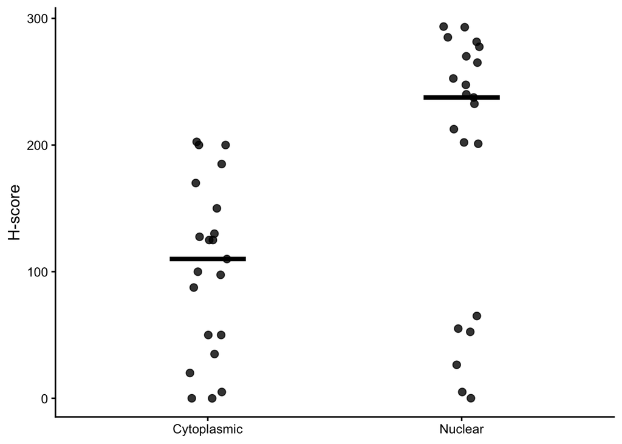

Figure 1: Distribution of baseline nuclear and cytoplasmic HES-1 H-scores.

# 2. HES-1 H-score as a continuous variable and survival

> **Question from Quentin:**  
> “Could you evaluate PFS and OS according to H-score, considering H-score as a continuous variable?”

## Statistical analysis

Nuclear and cytoplasmic HES-1 H-scores were analyzed separately using univariable Cox proportional hazards models.

For easier interpretation, H-scores were divided by 100. Hazard ratios therefore represent the change in hazard associated with a 100-point increase in H-score.

**Afficher le code R**

```r
cox_nuc_pfs <- coxph(
  Surv(pfs_days, pfs_event) ~ hscore_nuc_100,
  data = df
)

cox_nuc_os <- coxph(
  Surv(os_days, os_event) ~ hscore_nuc_100,
  data = df
)

cox_cyto_pfs <- coxph(
  Surv(pfs_days, pfs_event) ~ hscore_cyto_100,
  data = df
)

cox_cyto_os <- coxph(
  Surv(os_days, os_event) ~ hscore_cyto_100,
  data = df
)
```

## Results

| Outcome | Predictor | Scale | N | Events | HR [95% CI] | p-value |
| --- | --- | --- | --- | --- | --- | --- |
| PFS | Nuclear H-score | +100 points | 21 | 18 | 1.54 [0.94–2.53] | 0.087 |
| OS | Nuclear H-score | +100 points | 21 | 12 | 1.22 [0.70–2.10] | 0.483 |
| PFS | Cytoplasmic H-score | +100 points | 21 | 18 | 1.43 [0.64–3.22] | 0.384 |
| OS | Cytoplasmic H-score | +100 points | 21 | 12 | 1.56 [0.62–3.93] | 0.341 |

A HR greater than 1 indicates a higher hazard associated with increasing H-score, whereas a HR below 1 indicates a lower hazard.

# 3. Nuclear HES-1 H-score categories and survival

> **Question from Quentin:**  
> “For nuclear H-score, patients with an H-score <100 were classified as low and patients with an H-score >200 as high.”

## Statistical analysis

Only nuclear H-score was categorized.

- Low nuclear H-score: <100
- High nuclear H-score: >200

Patients with values between 100 and 200 were excluded from this categorical comparison.

PFS and OS were estimated using Kaplan-Meier survival curves and compared using the log-rank test. Cox regression was used to estimate the hazard ratio for High versus Low H-score.

## Group composition

| Group | N |
| --- | --- |
| Low | 6 |
| High | 15 |

## Progression-free survival

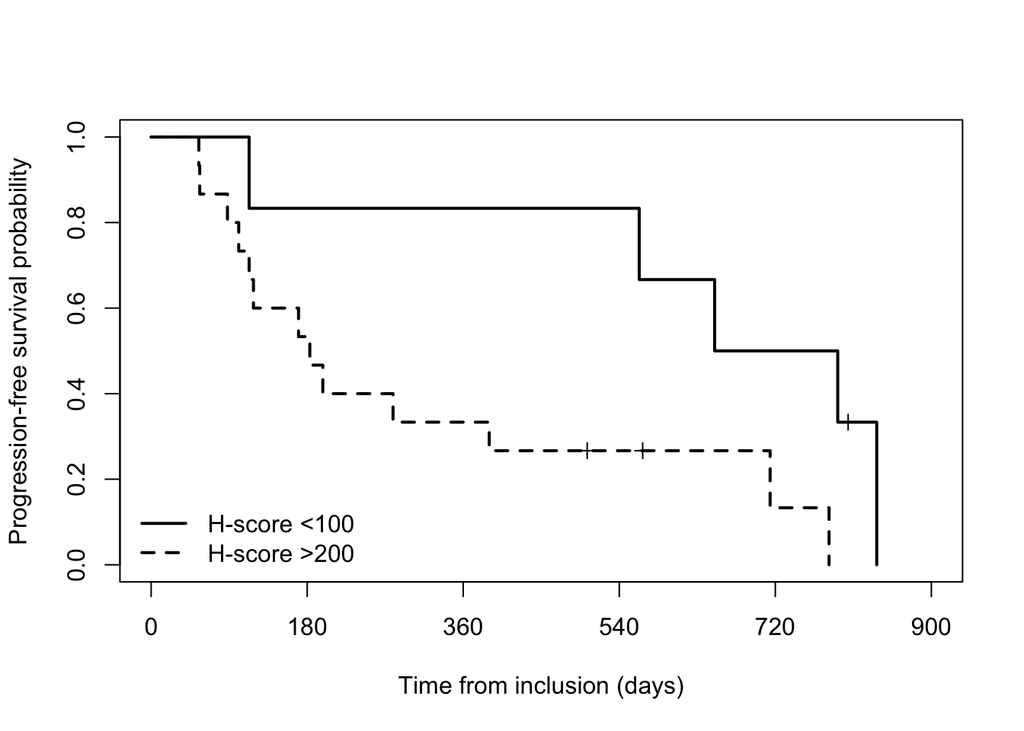

Number at risk

| Group | 0 | 180 | 360 | 540 | 720 | 900 |
| --- | --- | --- | --- | --- | --- | --- |
| Low | 6 | 5 | 5 | 5 | 3 | 0 |
| High | 15 | 8 | 5 | 3 | 1 | 0 |

| Test | p-value |
| --- | --- |
| Log-rank | 0.034 |

## Overall survival

[figure not shown]

Number at risk

| Group | 0 | 180 | 360 | 540 | 720 | 900 |
| --- | --- | --- | --- | --- | --- | --- |
| Low | 6 | 5 | 5 | 5 | 3 | 0 |
| High | 15 | 12 | 9 | 3 | 2 | 1 |

| Test | p-value |
| --- | --- |
| Log-rank | 0.308 |

Survival summary according to nuclear H-score

| Outcome | Group | N | Events | Median survival |
| --- | --- | --- | --- | --- |
| PFS | Low | 6 | 5 | 721 days (23.7 months) |
| PFS | High | 15 | 13 | 183 days (6.0 months) |
| OS | Low | 6 | 3 | 795 days (26.1 months) |
| OS | High | 15 | 9 | 491 days (16.1 months) |

## Cox estimates

**Afficher le code R**

```r
cox_hscore_group_pfs <- coxph(
  Surv(pfs_days, pfs_event) ~ hscore_group,
  data = df_nuc
)

cox_hscore_group_os <- coxph(
  Surv(os_days, os_event) ~ hscore_group,
  data = df_nuc
)
```

| Outcome | Predictor | Scale | N | Events | HR [95% CI] | p-value |
| --- | --- | --- | --- | --- | --- | --- |
| PFS | Nuclear H-score | >200 vs <100 | 21 | 18 | 3.76 [1.02–13.77] | 0.046 |
| OS | Nuclear H-score | >200 vs <100 | 21 | 12 | 1.99 [0.52–7.68] | 0.316 |

# 4. Baseline circulating tumor cells and survival

> **Question from Quentin:**  
> “Could you also evaluate PFS and OS according to CTC at inclusion?”

## Statistical analysis

Baseline CTC status was analyzed as a binary variable. Patients with a CTC value equal to 0 were classified as CTC absent, whereas patients with a CTC value greater than 0 were classified as CTC present. Patients with missing baseline CTC data were excluded from this analysis.

PFS and OS were compared according to baseline CTC status using Kaplan-Meier estimates, log-rank tests, and univariable Cox proportional hazards models.

## Group composition

| CTC status | N |
| --- | --- |
| Absent | 17 |
| Present | 7 |

## Progression-free survival

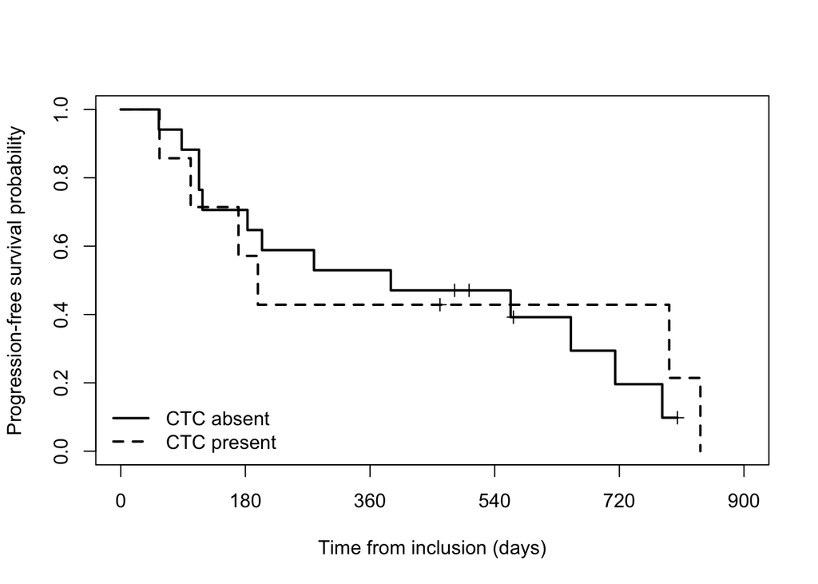

Number at risk

| Group | 0 | 180 | 360 | 540 | 720 | 900 |
| --- | --- | --- | --- | --- | --- | --- |
| Absent | 17 | 12 | 9 | 6 | 2 | 0 |
| Present | 7 | 4 | 3 | 2 | 2 | 0 |

## Overall survival

[figure not shown]

Number at risk

| Group | 0 | 180 | 360 | 540 | 720 | 900 |
| --- | --- | --- | --- | --- | --- | --- |
| Absent | 17 | 14 | 13 | 7 | 5 | 1 |
| Present | 7 | 6 | 4 | 2 | 1 | 0 |

Survival summary according to baseline CTC status

| Outcome | Group | N | Events | Median survival |
| --- | --- | --- | --- | --- |
| PFS | Absent | 17 | 13 | 390 days (12.8 months) |
| PFS | Present | 7 | 6 | 198 days (6.5 months) |
| OS | Absent | 17 | 9 | 772 days (25.4 months) |
| OS | Present | 7 | 4 | 491 days (16.1 months) |

## Cox estimates

**Afficher le code R**

```r
cox_ctc_pfs <- coxph(
  Surv(pfs_days, pfs_event) ~ ctc_status,
  data = df_ctc
)

cox_ctc_os <- coxph(
  Surv(os_days, os_event) ~ ctc_status,
  data = df_ctc
)
```

| Outcome | Predictor | Scale | N | Events | HR [95% CI] | p-value |
| --- | --- | --- | --- | --- | --- | --- |
| PFS | Baseline CTC status | Present vs Absent | 24 | 19 | 0.84 [0.29–2.44] | 0.753 |
| OS | Baseline CTC status | Present vs Absent | 24 | 13 | 1.33 [0.41–4.36] | 0.635 |

# 5. Baseline circulating tumor DNA and survival

> **Question from Quentin:**  
> “Could you perform the same analysis using circulating tumor DNA?”

## Statistical analysis

Baseline ctDNA was analyzed as a continuous variable using separate univariable Cox proportional hazards models for PFS and OS.

For easier interpretation, ctDNA values were divided by 100. Hazard ratios therefore represent a 100-unit increase in baseline ctDNA.

**Afficher le code R**

```r
cox_ctdna_pfs <- coxph(
  Surv(pfs_days, pfs_event) ~ ctdna_t1_100,
  data = df
)

cox_ctdna_os <- coxph(
  Surv(os_days, os_event) ~ ctdna_t1_100,
  data = df
)
```

## Results

| Outcome | Predictor | Scale | N | Events | HR [95% CI] | p-value |
| --- | --- | --- | --- | --- | --- | --- |
| PFS | Baseline ctDNA | +100 units | 24 | 19 | 1.02 [0.99–1.05] | 0.221 |
| OS | Baseline ctDNA | +100 units | 24 | 13 | 1.04 [1.00–1.07] | 0.028 |

# 6. ctDNA clearance at T2 and survival

> **Question from Quentin:**  
> “Could you also evaluate survival according to clearance of circulating tumor DNA at T2, i.e. patients with no remaining ctDNA (value 0) versus the others?”

## Statistical analysis

Patients with a T2 ctDNA value equal to 0 were classified as having ctDNA clearance.

Patients with a T2 ctDNA value greater than 0 were classified as having no clearance.

Patients with missing T2 ctDNA were excluded.

## Group composition

| Group | N |
| --- | --- |
| No clearance | 8 |
| Clearance | 15 |

## Progression-free survival

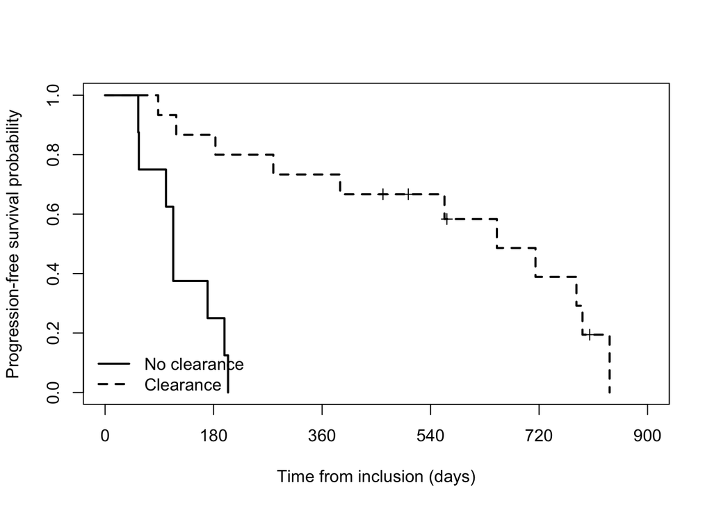

Number at risk

| Group | 0 | 180 | 360 | 540 | 720 | 900 |
| --- | --- | --- | --- | --- | --- | --- |
| No clearance | 8 | 2 | 0 | 0 | 0 | 0 |
| Clearance | 15 | 13 | 11 | 8 | 4 | 0 |

| Test | p-value |
| --- | --- |
| Log-rank | <0.001 |

## Overall survival

[figure not shown]

Number at risk

| Group | 0 | 180 | 360 | 540 | 720 | 900 |
| --- | --- | --- | --- | --- | --- | --- |
| No clearance | 8 | 5 | 2 | 1 | 1 | 0 |
| Clearance | 15 | 14 | 14 | 8 | 5 | 1 |

| Test | p-value |
| --- | --- |
| Log-rank | <0.001 |

Survival summary according to ctDNA clearance at T2

| Outcome | Group | N | Events | Median survival | 95% CI |
| --- | --- | --- | --- | --- | --- |
| PFS | No clearance | 8 | 8 | 113 days (3.7 months) | Not estimable |
| PFS | Clearance | 15 | 11 | 650 days (21.4 months) | Not estimable |
| OS | No clearance | 8 | 8 | 216 days (7.1 months) | Not estimable |
| OS | Clearance | 15 | 5 | Not reached | Not estimable |

## Cox estimates

**Afficher le code R**

```r
cox_clearance_pfs <- coxph(
  Surv(pfs_days, pfs_event) ~ clearance,
  data = df_clearance
)

cox_clearance_os <- coxph(
  Surv(os_days, os_event) ~ clearance,
  data = df_clearance
)
```

| Outcome | Predictor | Scale | N | Events | HR [95% CI] | p-value |
| --- | --- | --- | --- | --- | --- | --- |
| PFS | ctDNA clearance at T2 | Clearance vs No clearance | 23 | 19 | 0.09 [0.02–0.37] | <0.001 |
| OS | ctDNA clearance at T2 | Clearance vs No clearance | 23 | 13 | 0.12 [0.03–0.41] | <0.001 |

# 7. Summary of requested survival analyses

Summary of univariable survival analyses

Hazard ratios with 95% confidence intervals

| Outcome | Predictor | Scale | N | Events | HR [95% CI] | p-value |
| --- | --- | --- | --- | --- | --- | --- |
| OS | Baseline CTC status | Present vs Absent | 24 | 13 | 1.33 [0.41–4.36] | 0.635 |
| OS | Baseline ctDNA | +100 units | 24 | 13 | 1.04 [1.00–1.07] | 0.028 |
| OS | Cytoplasmic H-score | +100 points | 21 | 12 | 1.56 [0.62–3.93] | 0.341 |
| OS | Nuclear H-score | +100 points | 21 | 12 | 1.22 [0.70–2.10] | 0.483 |
| OS | Nuclear H-score | >200 vs <100 | 21 | 12 | 1.99 [0.52–7.68] | 0.316 |
| OS | ctDNA clearance at T2 | Clearance vs No clearance | 23 | 13 | 0.12 [0.03–0.41] | <0.001 |
| PFS | Baseline CTC status | Present vs Absent | 24 | 19 | 0.84 [0.29–2.44] | 0.753 |
| PFS | Baseline ctDNA | +100 units | 24 | 19 | 1.02 [0.99–1.05] | 0.221 |
| PFS | Cytoplasmic H-score | +100 points | 21 | 18 | 1.43 [0.64–3.22] | 0.384 |
| PFS | Nuclear H-score | +100 points | 21 | 18 | 1.54 [0.94–2.53] | 0.087 |
| PFS | Nuclear H-score | >200 vs <100 | 21 | 18 | 3.76 [1.02–13.77] | 0.046 |
| PFS | ctDNA clearance at T2 | Clearance vs No clearance | 23 | 19 | 0.09 [0.02–0.37] | <0.001 |

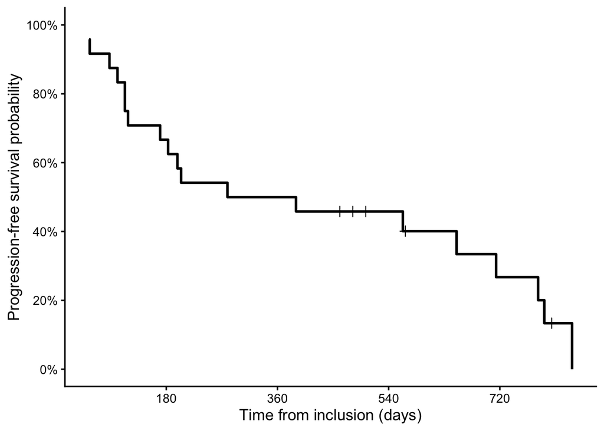

Number at risk

| Group | 0 | 180 | 360 | 540 | 720 | 900 |
| --- | --- | --- | --- | --- | --- | --- |
| Overall cohort | 24 | 16 | 12 | 8 | 4 | 0 |

Median progression-free survival of the entire cohort

| Population | Median PFS |
| --- | --- |
| Overall cohort | 334 days (11.0 months) |

# Overall survival of the entire cohort

> **Overall cohort analysis:**  
> Overall survival was estimated using the Kaplan-Meier method for the entire study population. Censored observations are indicated by vertical marks. The number of patients at risk is reported below the survival curve.

Number at risk

| Group | 0 | 180 | 360 | 540 | 720 | 900 |
| --- | --- | --- | --- | --- | --- | --- |
| Overall cohort | 24 | 20 | 17 | 9 | 6 | 1 |

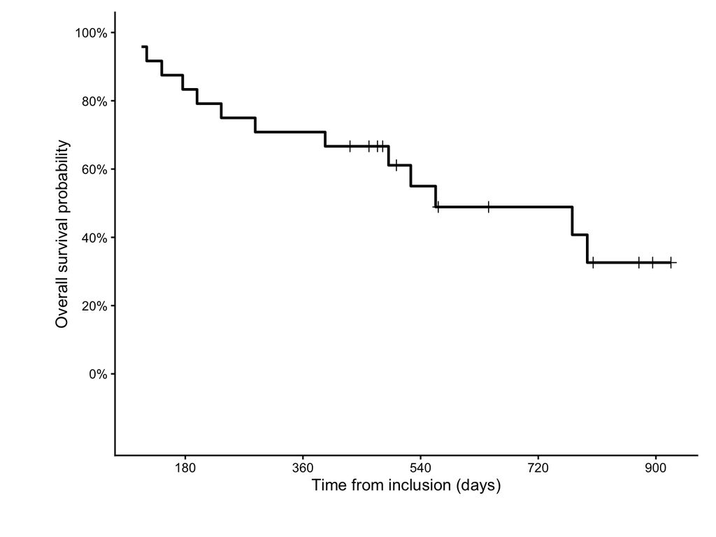

Overall survival outcomes in the complete cohort

[output not shown]

Overall survival events

| Patients | Deaths | Censored |
| --- | --- | --- |
| 24 | 13 | 11 |

# Statistical interpretation

These analyses are exploratory and univariable.

# Publication figures

The following figures reproduce the survival analyses presented above using a standardized graphical format intended for publication. No statistical analysis was recalculated or modified.

## Nuclear H-score

### Progression-free survival

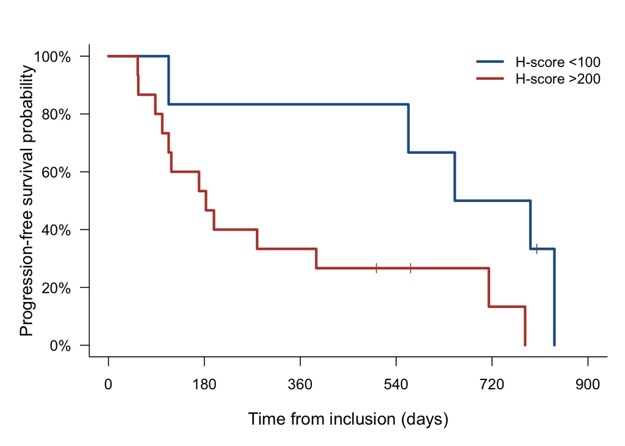

### Overall survival

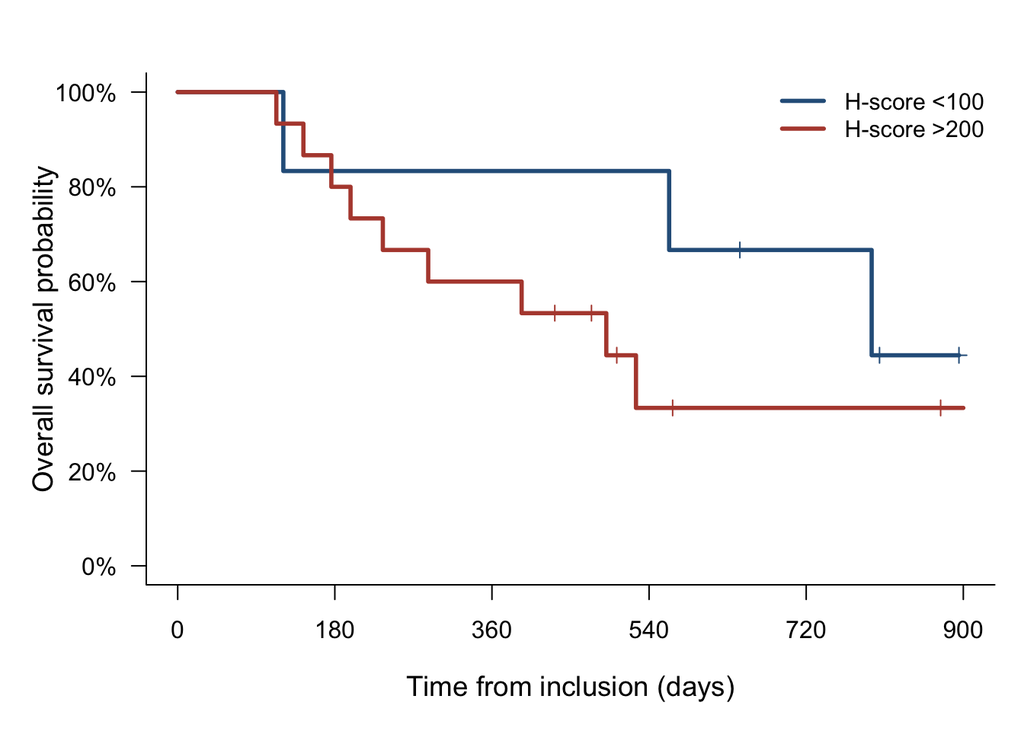

## Baseline CTC status

### Progression-free survival

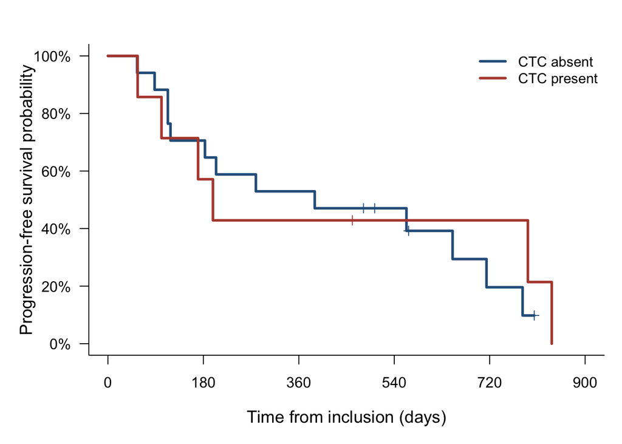

### Overall survival

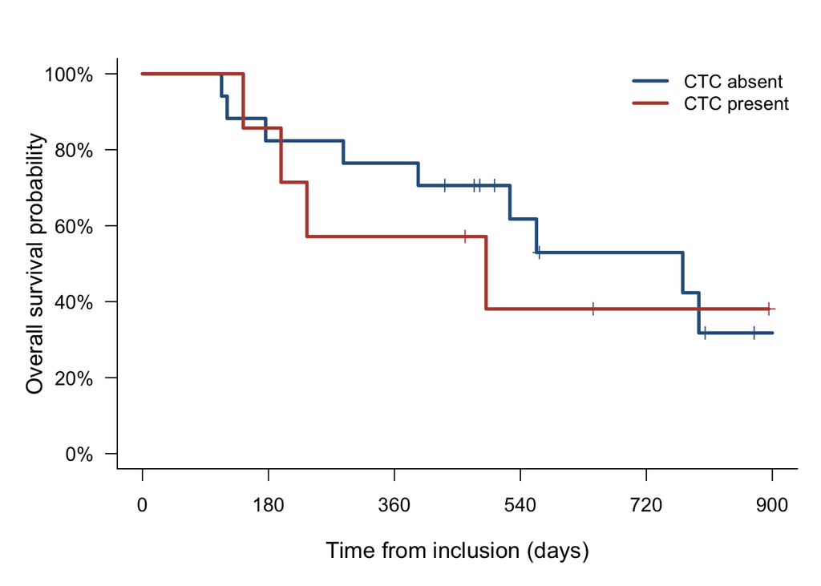

## ctDNA clearance at T2

### Progression-free survival

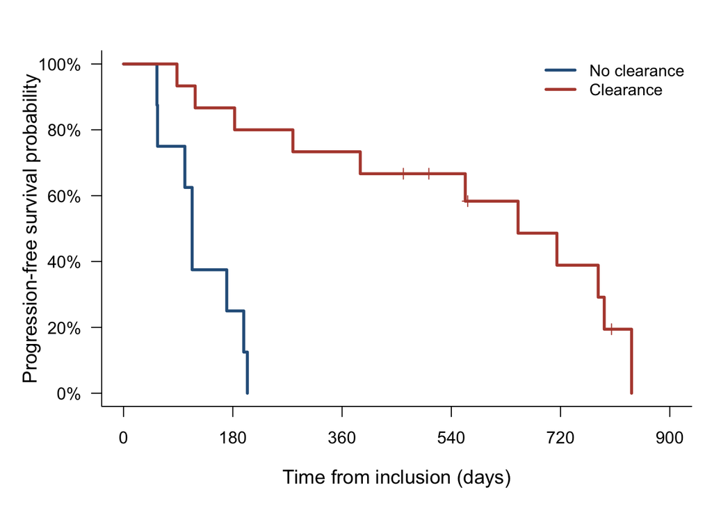

### Overall survival

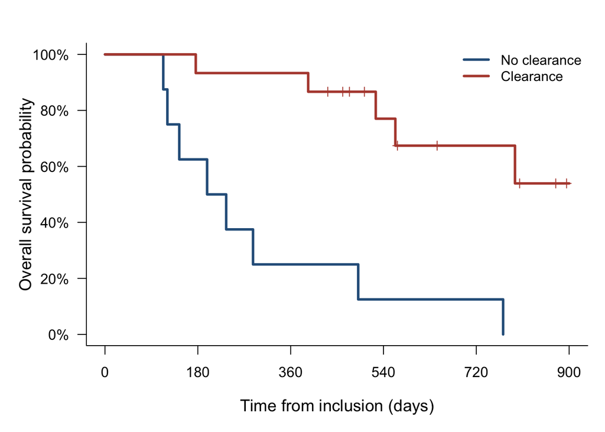

## Overall cohort

### Progression-free survival

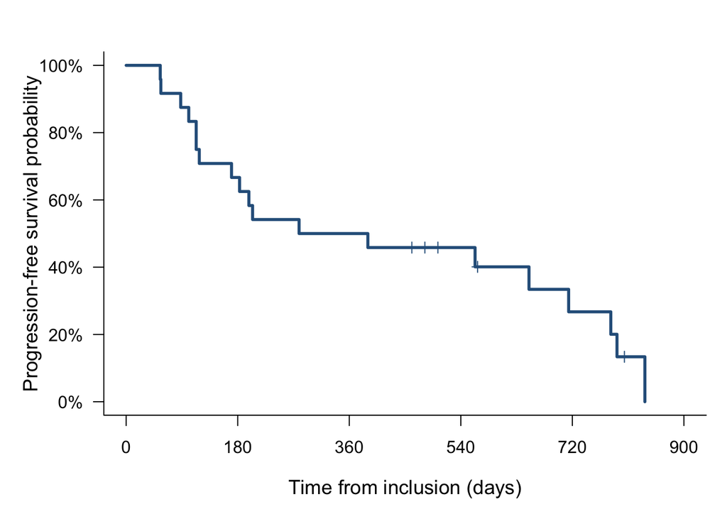

### Overall survival

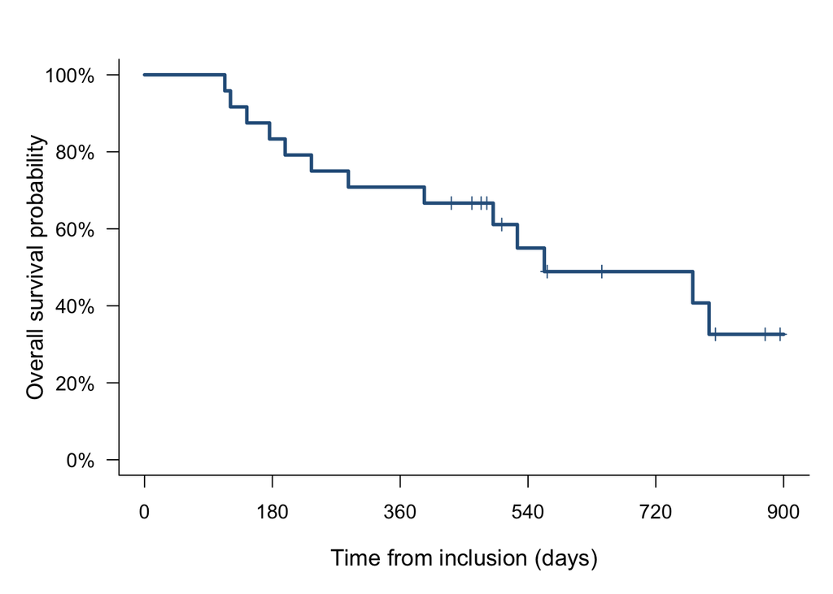

# ANALYSES COMPLEMENTAIRES

The following complementary analyses were performed following additional requests.

# 1. 95% confidence intervals for median PFS and OS

> **Question:** “Could you provide 95% confidence intervals for PFS and OS?”

## Statistical analysis

Median progression-free survival (PFS) and overall survival (OS) were estimated using the Kaplan–Meier method.  
95% confidence intervals are reported whenever estimable. Because of the limited sample size and number of events, one or both confidence interval limits may not be estimable.

Median progression-free and overall survival

Kaplan–Meier estimates with 95% confidence intervals

| Outcome | N | Events | Median survival | 95% CI |
| --- | --- | --- | --- | --- |
| Progression-free survival | 24 | 19 | 334 days (11.0 months) | 183–792 days |
| Overall survival | 24 | 13 | 563 days (18.5 months) | 491–NA days |

## Interpretation

Median survival estimates should be interpreted cautiously because of the limited sample size.  
When a confidence interval boundary cannot be estimated, it is reported as NA rather than being replaced or extrapolated.

# 2. PFS and OS rates at 6 and 18 months

> **Question:** “Could you provide PFS and OS rates at 6 months and 18 months?”

## Statistical analysis

Kaplan–Meier estimates of PFS and OS were calculated at 6 months (180 days) and 18 months (540 days).  
Results are expressed as percentages with 95% confidence intervals.

### Overall cohort

PFS and OS rates at 6 and 18 months — Overall cohort

| Analysis | Outcome | Group | Time | Number at risk | Survival rate | 95% CI |
| --- | --- | --- | --- | --- | --- | --- |
| Overall cohort | PFS | Overall cohort | 6 months | 16 | 66.7% | 50.2–88.5% |
| Overall cohort | PFS | Overall cohort | 18 months | 8 | 45.8% | 29.7–70.8% |
| Overall cohort | OS | Overall cohort | 6 months | 20 | 83.3% | 69.7–99.7% |
| Overall cohort | OS | Overall cohort | 18 months | 9 | 55.0% | 37.3–81.2% |

### Nuclear H-score groups

PFS and OS rates at 6 and 18 months — Nuclear H-score

| Analysis | Outcome | Group | Time | Number at risk | Survival rate | 95% CI |
| --- | --- | --- | --- | --- | --- | --- |
| Nuclear H-score | PFS | Low | 6 months | 5 | 83.3% | 58.3–100.0% |
| Nuclear H-score | PFS | Low | 18 months | 5 | 83.3% | 58.3–100.0% |
| Nuclear H-score | PFS | High | 6 months | 8 | 53.3% | 33.2–85.6% |
| Nuclear H-score | PFS | High | 18 months | 3 | 26.7% | 11.5–61.7% |
| Nuclear H-score | OS | Low | 6 months | 5 | 83.3% | 58.3–100.0% |
| Nuclear H-score | OS | Low | 18 months | 5 | 83.3% | 58.3–100.0% |
| Nuclear H-score | OS | High | 6 months | 12 | 80.0% | 62.1–100.0% |
| Nuclear H-score | OS | High | 18 months | 3 | 33.3% | 14.7–75.7% |

### Baseline CTC status

PFS and OS rates at 6 and 18 months — Baseline CTC

| Analysis | Outcome | Group | Time | Number at risk | Survival rate | 95% CI |
| --- | --- | --- | --- | --- | --- | --- |
| Baseline CTC | PFS | Absent | 6 months | 12 | 70.6% | 51.9–95.9% |
| Baseline CTC | PFS | Absent | 18 months | 6 | 47.1% | 28.4–77.9% |
| Baseline CTC | PFS | Present | 6 months | 4 | 57.1% | 30.1–100.0% |
| Baseline CTC | PFS | Present | 18 months | 2 | 42.9% | 18.2–100.0% |
| Baseline CTC | OS | Absent | 6 months | 14 | 82.4% | 66.1–100.0% |
| Baseline CTC | OS | Absent | 18 months | 7 | 61.8% | 41.3–92.5% |
| Baseline CTC | OS | Present | 6 months | 6 | 85.7% | 63.3–100.0% |
| Baseline CTC | OS | Present | 18 months | 2 | 38.1% | 13.7–100.0% |

## Interpretation

These percentages correspond to Kaplan–Meier survival estimates and not to crude proportions of surviving patients.  
The confidence intervals reflect the uncertainty associated with the limited sample size.

# 3. Corrected analysis of ctDNA clearance at T2

> **Question:** “Patients without detectable ctDNA at baseline cannot experience ctDNA clearance. Patients 15, 19 and 46 should therefore be excluded from the clearance analysis.”

## Statistical analysis

ctDNA clearance was evaluated only among patients with detectable ctDNA at baseline (T1).

Patients were classified as:

- **Clearance:** detectable ctDNA at T1 followed by ctDNA = 0 at T2.
- **No clearance:** detectable ctDNA at T1 and persistent detectable ctDNA at T2.

Patients with ctDNA = 0 at baseline were excluded because clearance cannot be defined in these patients.

## Verification of excluded patients

Patients excluded because ctDNA was absent at baseline

| id | ctdna_t1 | ctdna_t2 |
| --- | --- | --- |
| 11-01-15 | 0 | 0 |
| 11-01-19 | 0 | 0 |
| 11-01-46 | 0 | NA |

This table should identify patients 15, 19 and 46.

## Group composition

Corrected ctDNA clearance groups

| Group | N |
| --- | --- |
| No clearance | 8 |
| Clearance | 13 |

## Progression-free survival

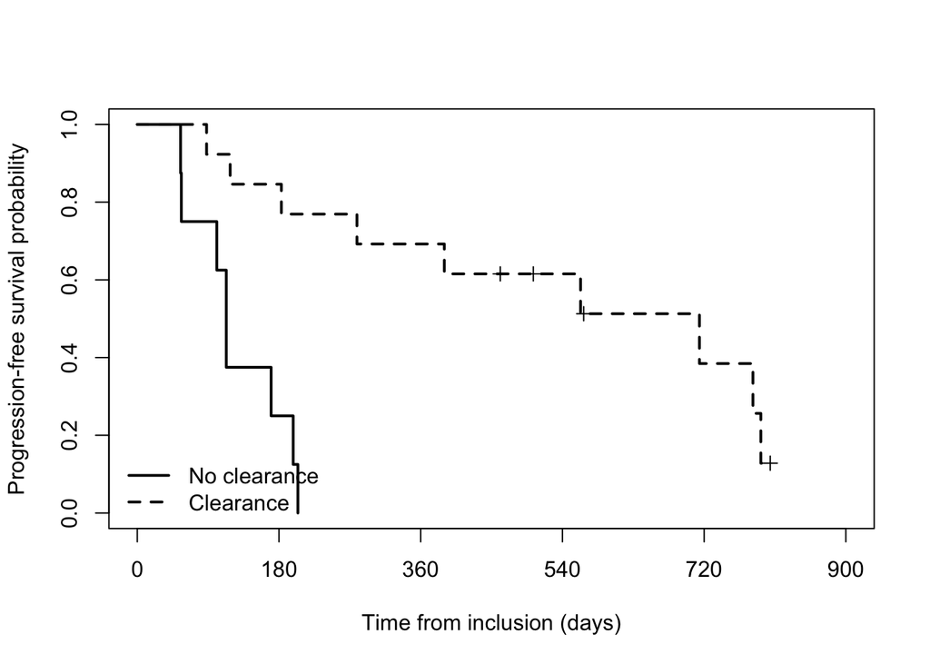

Number at risk — Progression-free survival

| Group | 0 | 180 | 360 | 540 | 720 | 900 |
| --- | --- | --- | --- | --- | --- | --- |
| No clearance | 8 | 2 | 0 | 0 | 0 | 0 |
| Clearance | 13 | 11 | 9 | 6 | 3 | 0 |

### Log-rank test

| Test | p-value |
| --- | --- |
| Log-rank | 0.000 |

## Overall survival

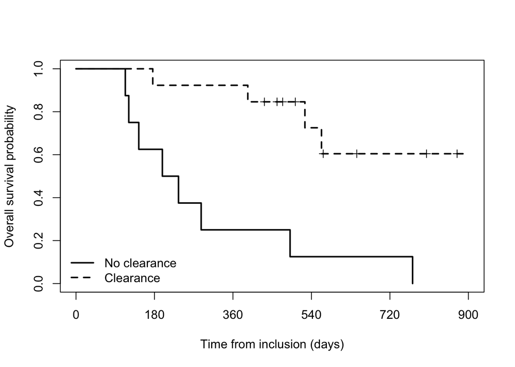

Number at risk — Overall survival

| Group | 0 | 180 | 360 | 540 | 720 | 900 |
| --- | --- | --- | --- | --- | --- | --- |
| No clearance | 8 | 5 | 2 | 1 | 1 | 0 |
| Clearance | 13 | 12 | 12 | 6 | 3 | 1 |

### Log-rank test

| Test | p-value |
| --- | --- |
| Log-rank | 0.001 |

## Survival summary

Survival summary according to ctDNA clearance at T2

Corrected analysis excluding patients without detectable baseline ctDNA

| Outcome | Group | N | Events | Median survival | 95% CI |
| --- | --- | --- | --- | --- | --- |
| PFS | No clearance | 8 | 8 | 113 days (3.7 months) | 101–NA days |
| PFS | Clearance | 13 | 9 | 714 days (23.5 months) | 279–NA days |
| OS | No clearance | 8 | 8 | 216 days (7.1 months) | 144–NA days |
| OS | Clearance | 13 | 4 | Not reached | 525–NA days |

## Cox proportional hazards models

**Afficher le code R**

```r
cox_clearance_pfs_corrected <- coxph(
  Surv(
    pfs_days,
    pfs_event
  ) ~ clearance,
  data = df_clearance_corrected
)

cox_clearance_os_corrected <- coxph(
  Surv(
    os_days,
    os_event
  ) ~ clearance,
  data = df_clearance_corrected
)
```

Corrected survival analysis according to ctDNA clearance at T2

| Outcome | Predictor | Scale | N | Events | HR [95% CI] | p-value |
| --- | --- | --- | --- | --- | --- | --- |
| PFS | ctDNA clearance at T2 | Clearance vs No clearance | 21 | 17 | 0.11 [0.03–0.43] | 0.002 |
| OS | ctDNA clearance at T2 | Clearance vs No clearance | 21 | 12 | 0.15 [0.04–0.51] | 0.002 |

## PFS and OS rates at 6 and 18 months after correction

PFS and OS rates at 6 and 18 months according to corrected ctDNA clearance

| Analysis | Outcome | Group | Time | Number at risk | Survival rate | 95% CI |
| --- | --- | --- | --- | --- | --- | --- |
| ctDNA clearance | PFS | No clearance | 6 months | 2 | 25.0% | 7.5–83.0% |
| ctDNA clearance | PFS | Clearance | 6 months | 11 | 84.6% | 67.1–100.0% |
| ctDNA clearance | PFS | Clearance | 18 months | 6 | 61.5% | 40.0–94.6% |
| ctDNA clearance | OS | No clearance | 6 months | 5 | 62.5% | 36.5–100.0% |
| ctDNA clearance | OS | No clearance | 18 months | 1 | 12.5% | 2.0–78.2% |
| ctDNA clearance | OS | Clearance | 6 months | 12 | 92.3% | 78.9–100.0% |
| ctDNA clearance | OS | Clearance | 18 months | 6 | 72.5% | 49.5–100.0% |

## Interpretation

This corrected analysis excludes patients without detectable baseline ctDNA because these patients are not at risk of experiencing ctDNA clearance.

The analysis remains exploratory because of the limited number of patients and events.

# 4. Overall survival according to ctDNA at relapse (T4)

> **Question:** “Could you evaluate overall survival according to ctDNA at relapse (T4), both as a continuous variable and as a binary variable (present versus absent)?”

## Statistical analysis

Overall survival was evaluated from the T4 assessment using the dedicated survival variables.

ctDNA at T4 was analyzed:

1. as a continuous variable using a univariable Cox proportional hazards model;
2. as a binary variable, with ctDNA classified as absent when equal to 0 and present when greater than 0.

Patients with missing ctDNA at T4 or missing survival information were excluded.

## Population included in the T4 analysis

Population included in the ctDNA T4 survival analysis

| Patients | Deaths | Censored | ctDNA absent | ctDNA present |
| --- | --- | --- | --- | --- |
| 15 | 9 | 6 | 4 | 11 |

# 4.1. ctDNA at T4 as a continuous variable

## Cox proportional hazards model

ctDNA at T4 was first analyzed as a continuous predictor of overall survival from T4.

For easier interpretation, ctDNA was divided by 100. The hazard ratio therefore represents the change in the hazard of death associated with a 100-unit increase in ctDNA at T4.

**Afficher le code R**

```r
df_t4 <- df_t4 |>
  mutate(
    ctdna_t4_100 = adntc_t4 / 100
  )

cox_ctdna_t4_continuous <- coxph(
  Surv(
    os_adntc_t4,
    event_t4
  ) ~ ctdna_t4_100,
  data = df_t4
)
```

## Results

Association between ctDNA at T4 and overall survival

ctDNA analyzed as a continuous variable

| Outcome | Predictor | Scale | N | Events | HR [95% CI] | p-value |
| --- | --- | --- | --- | --- | --- | --- |
| OS from T4 | ctDNA at T4 | +100 units | 15 | 9 | 1.03 [0.99–1.06] | 0.134 |

A hazard ratio greater than 1 indicates an increasing hazard of death with increasing ctDNA at T4.

# 4.2. ctDNA at T4 as a binary variable

ctDNA at T4 was classified as:

- **Absent:** ctDNA = 0
- **Present:** ctDNA > 0

Overall survival from T4 was estimated using the Kaplan–Meier method and compared using the log-rank test.

## Group composition

| ctDNA status at T4 | N |
| --- | --- |
| Absent | 4 |
| Present | 11 |

## Kaplan–Meier overall survival

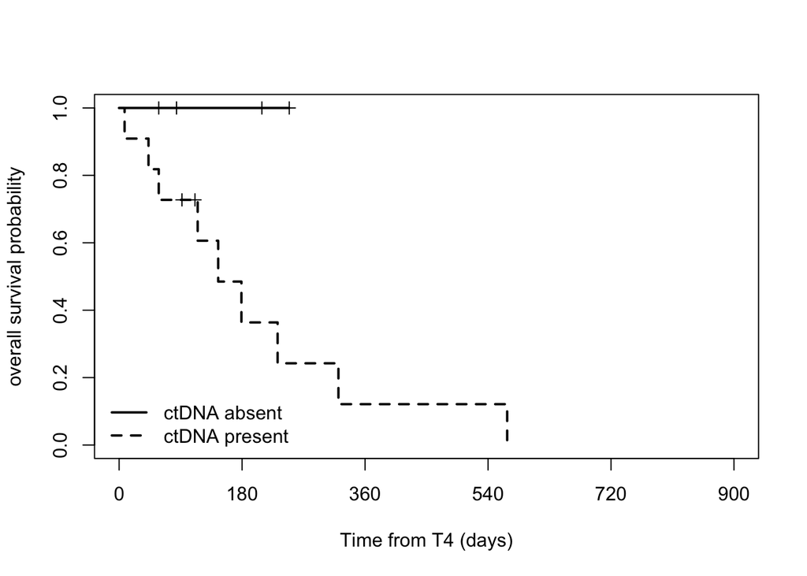

Number at risk — Overall survival from T4

| Group | 0 | 180 | 360 | 540 | 720 | 900 |
| --- | --- | --- | --- | --- | --- | --- |
| Absent | 4 | 2 | 0 | 0 | 0 | 0 |
| Present | 11 | 3 | 1 | 1 | 0 | 0 |

## Log-rank test

| Test | p-value |
| --- | --- |
| Log-rank | 0.096 |

## Median overall survival with 95% confidence intervals

Overall survival from T4 according to ctDNA status

| Group | N | Events | Median OS | 95% CI |
| --- | --- | --- | --- | --- |
| Absent | 4 | 0 | Not reached | NA–NA days |
| Present | 11 | 9 | 145 days (4.8 months) | 115–NA days |

## Overall survival rates at 6 and 18 months

Overall survival rates at 6 and 18 months from T4

| Analysis | Outcome | Group | Time | Number at risk | Survival rate | 95% CI |
| --- | --- | --- | --- | --- | --- | --- |
| ctDNA at T4 | OS from T4 | Absent | 6 months | 2 | 100.0% | 100.0–100.0% |
| ctDNA at T4 | OS from T4 | Present | 6 months | 3 | 36.4% | 15.1–87.5% |
| ctDNA at T4 | OS from T4 | Present | 18 months | 1 | 12.1% | 2.0–75.2% |

## Cox proportional hazards model

**Afficher le code R**

```r
cox_ctdna_t4_binary <- coxph(
  Surv(
    os_adntc_t4,
    event_t4
  ) ~ ctdna_t4_status,
  data = df_t4
)
```

Association between ctDNA status at T4 and overall survival

Present versus absent ctDNA

| Outcome | Predictor | Scale | N | Events | HR [95% CI] | p-value |
| --- | --- | --- | --- | --- | --- | --- |
| OS from T4 | ctDNA at T4 | Present vs Absent | 15 | 9 | 841637513.40 [0.00–Inf] | 0.999 |

## Interpretation

The continuous analysis evaluates the association between increasing ctDNA levels at relapse and the subsequent hazard of death.

The binary analysis compares overall survival from T4 between patients with detectable and undetectable ctDNA at relapse.

Because this analysis is restricted to patients reaching T4 with available ctDNA measurements, the results should be considered exploratory. Effect sizes and their 95% confidence intervals should be interpreted alongside statistical significance.